# A.01: R Basics

Oropendola

2024-22-08

## Setup

Remember that for a Markdown to run, every step of the code must be intact, including reading in data, requiring packages, and assigning data types (such as date columns). Do so in the R-chunk below before moving on to questions 11-15

```r
# read in csv file
Potato_Chips <- read.csv("data_week_01.csv",
                         stringsAsFactors = TRUE)
# require r packages
require(lubridate)
require (ggplot2)
# assign proper date column
Potato_Chips$Date <- ymd(Potato_Chips$date)
str(Potato_Chips$Date)
```

```
##  Date[1:8773], format: "1984-03-20" "1984-03-21" "1984-03-22" "1984-03-23" "1984-03-24" ...
```

## Question 11: ___ / 5 points

Using R’s base plotting package in the R-chunk below, create a histogram that displays the distribution of precipitation, labeling the x-axis with units, and providing a main title. Change the color so the bins are green.

*Preceptor rubric*

- __ 1 point: correct graph type
- __ 1 point: correct data variable
- __ 1 point: axis labels
- __ 1 point: color/fill formatting
- __ 1 point: title

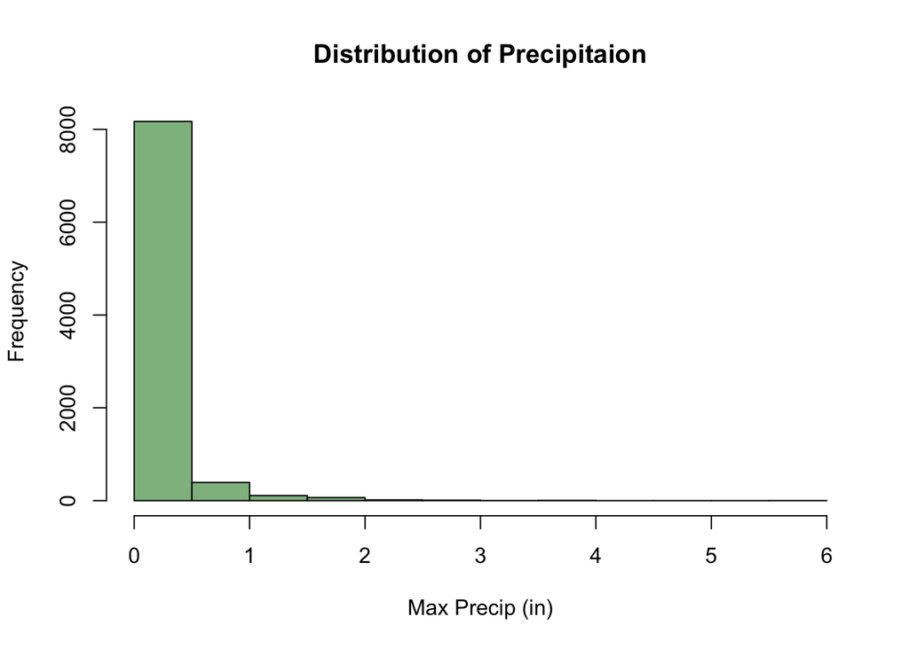

```r
hist(Potato_Chips$prcp,
     xlab = "Max Precip (in)",
     main = "Distribution of Precipitaion",
     col = "darkseagreen")
```

## Question 12: ___ / 5 points

Using ggplot2 in the R-chunk below, create a histogram that displays the distribution of precipitation, labeling the x-axis within units, providing the main title, and changing the fill of the histogram to be “hotpink”.

*Preceptor rubric*

- __ 1 point: correct graph type
- __ 1 point: correct data variable
- __ 1 point: axis labels
- __ 1 point: color/fill formatting
- __ 1 point: title

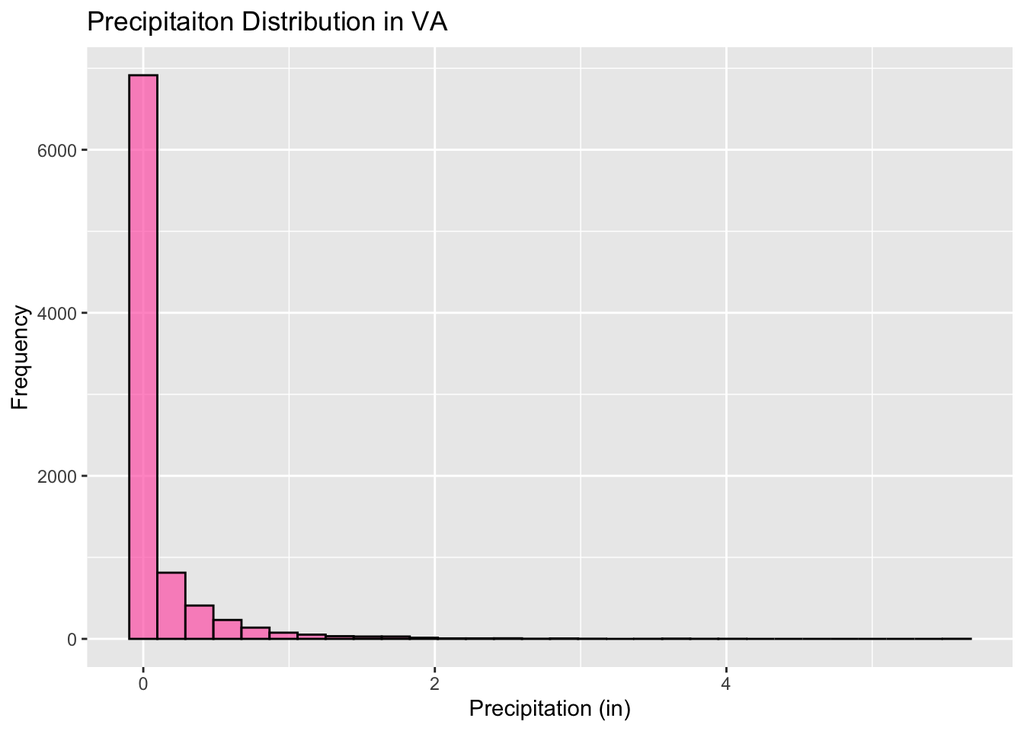

```r
ggplot(Potato_Chips,
       aes(x = prcp))+
  geom_histogram(fill = "hotpink",
                 color = "black",
                 alpha = 0.7)+
  labs(x = "Precipitation (in)",
       y = "Frequency",
       title = "Precipitaiton Distribution in VA")
```

## Question 13: ___ / 5 points

Using R’s base plotting package in the R-chunk below, create a scatterplot with the **maximum temperature** in degrees Fahrenheit on the x-axis and the **wind speed** in MPH on the y-axis. Format the axis labels and main title to have functional names.

*Preceptor rubric*

- __ 1 point: correct graph type
- __ 2 points: correct data placement (x/y)
- __ 1 point: axis labels
- __ 1 point: title

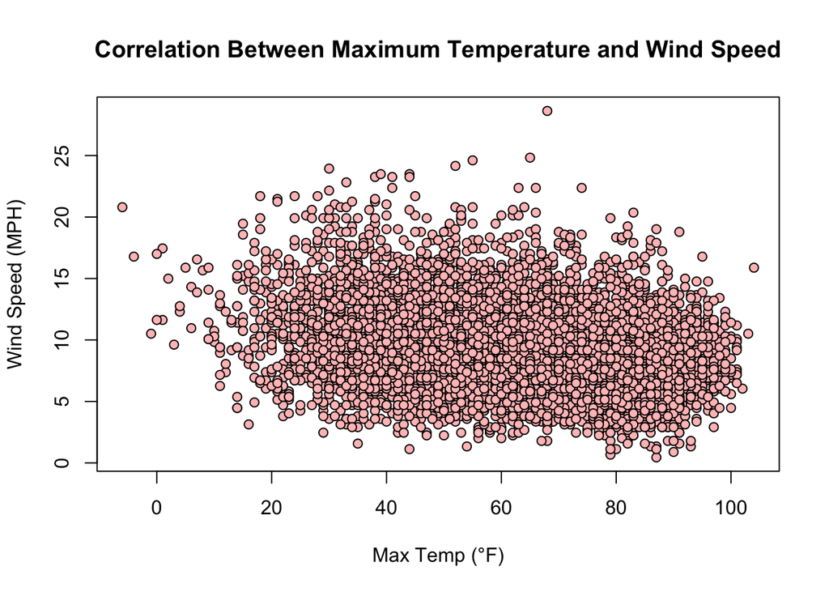

```r
plot(x = Potato_Chips$tmax,
     y = Potato_Chips$wind_speed,
     xlab = "Max Temp (°F)",
     ylab = "Wind Speed (MPH)",
     main = "Correlation Between Maximum Temperature and Wind Speed",
     pch = 21,
     bg = "rosybrown1",
     col = "black",
     cex = 1,
     lwd = 1)
```

## Question 14: ___ / 5 points

Using ggplot2 in the R-chunk below, create a scatterplot with the maximum temperature in degrees F on the x-axis and the wind speed in MPH on the y-axis. Color the points by weather station location. Format the axis labels (including units) and main title to have a short, functional name.

*Preceptor rubric*

- __ 1 point: correct graph type
- __ 1 point: correct data variable
- __ 1 point: axis labels
- __ 1 point: color/fill formatting
- __ 1 point: title

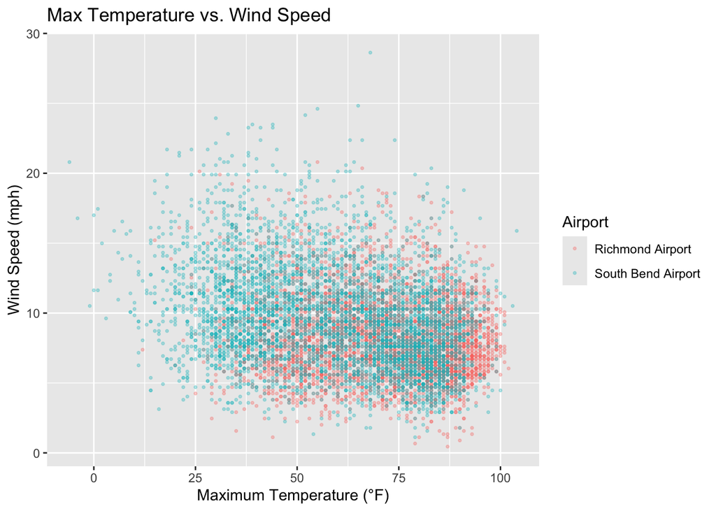

```r
ggplot(Potato_Chips,
       aes(x = tmax,
           y = wind_speed,
           color = station_location))+
  geom_point(alpha = 0.3,
             size = 1.1,
             shape = 20)+
  labs(x = "Maximum Temperature (°F)",
       y = "Wind Speed (mph)",
       title = "Max Temperature vs. Wind Speed",
       color = "Airport")
```

# Question 15: ___ / 5 points

For this last, most complicated graph, we want to look at the relationship between maximum temperature, wind speed, wind direction, and site.

In ggplot2, create a two-faceted graph with a scatterplot facet for each weather station location. They should each have the maximum temperature on the x-axis, and wind speed in mph on the y-axis. Points should be colored by the wind’s cardinal direction (N/E/S/W). Make sure the graph has a meaningful title, and the axes and color legend have formatted labels.

Because we are not using degrees for direction, this should NOT be plotted on with a polar coordinates.

*Preceptor rubric*

- __ 1 point: correct graph type
- __ 1 point: correct data variables (x/y)
- __ 1 points: facet arrangement
- __ 1 point: axis labels & title
- __ 1 point: legend label & point color

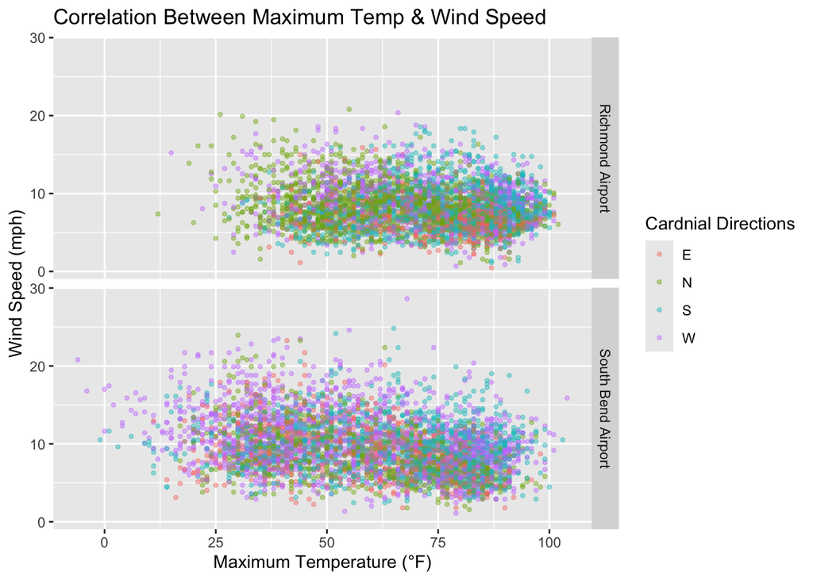

```r
ggplot(Potato_Chips,
       aes(x = tmax,
           y = wind_speed,
           color = wind_cardinal))+
  geom_point(alpha = 0.4,
             size = 1.5,
             shape = 20)+
  labs(x = "Maximum Temperature (°F)",
       y = "Wind Speed (mph)",
       title = "Correlation Between Maximum Temp & Wind Speed",
       color = "Cardnial Directions")+
  facet_grid(rows = vars(station_location))
```